# Data Analysis Project

# Introduction

We will be working with a dataset of auto claims filed by customers of an automobile insurance company located in the southwest and western regions of the United States.

Insurance companies depend on accurate pricing estimates to maintain profitability. Auto policies must be priced so that the insurance company makes a profit in the long run, given the costs of their customers’ payouts for accident repairs, total loss car replacements, medical fees, and legal fees.

The executives at this insurance company have noticed declining profitability over the last several years and have hired you as a data science consultant to evaluate their claims data and make recommendations on pricing, customer behavior, and car insurance policy adjustments.

The objective of this project is to perform an exploratory data analysis on the claims_df dataset and produce an executive summary of your key insights and recommendations to the executive team at the insurance company.

Before you begin, take a moment to read through the following insurance company terms to familiarize yourself with the industry: [Auto Insurance Terms](https://www.iii.org/article/auto-insurance-jargon-buster)

## Auto Claims Data

The `claims_df` data frame is loaded below and consists of 6,249 auto claims submitted by customers of the insurance company. The rows in this data frame represent a single claim with all of the associated features that are displayed in the table below.

**Note**: If you have not installed the `tidyverse` package, please do so by going to the `Packages` tab in the lower right section of RStudio, select the `Install` button and type `tidyverse` into the prompt. If you cannot load the data, then try downloading the latest version of R (at least 4.0). The `readRDS()` function has different behavior in older versions of `R` and may cause loading issues.

```r
installed.packages("tidyverse")
```

```
##      Package LibPath Version Priority Depends Imports LinkingTo Suggests
##      Enhances License License_is_FOSS License_restricts_use OS_type Archs
##      MD5sum NeedsCompilation Built
```

```r
library(tidyverse)
claims_df <- readRDS(url('https://gmubusinessanalytics.netlify.app/data/claims_df.rds'))
```

### Raw Data

```r
claims_df
```

| customer_id | customer_state | highest_education | employment_status | gender | income | residence_type | marital_status | sales_channel | coverage | policy | vehicle_class | vehicle_size | monthly_premium | months_policy_active | months_since_last_claim | current_claim_amount | total_claims | total_claims_amount | customer_lifetime_value |
| --- | --- | --- | --- | --- | --- | --- | --- | --- | --- | --- | --- | --- | --- | --- | --- | --- | --- | --- | --- |
| AA11235 | Nevada | Bachelor | Medical Leave | Female | 11167 | Suburban | Married | Branch | Basic | Personal | Two-Door Car | Midsize | 73 | 25 | 0 | 1383 | 1 | 1383 | 442 |
| AA16582 | Washington | Bachelor | Medical Leave | Male | 14072 | Suburban | Divorced | Agent | Basic | Personal | Four-Door Car | Midsize | 71 | 27 | 13 | 1379 | 2 | 1992 | -75 |
| AA34092 | California | Associate | Employed | Male | 33635 | Suburban | Married | Web | Extended | Personal | Luxury SUV | Midsize | 240 | 32 | 1 | 2633 | 2 | 3671 | 4009 |
| AA56476 | Arizona | High School | Employed | Female | 74454 | Suburban | Single | Call Center | Basic | Corporate | Four-Door Car | Midsize | 71 | 39 | 25 | 906 | 2 | 1541 | 1228 |
| AA69265 | Nevada | Bachelor | Employed | Female | 60817 | Suburban | Single | Web | Premium | Personal | Four-Door Car | Midsize | 103 | 21 | 3 | 1095 | 2 | 1760 | 403 |
| AA71604 | Arizona | Master | Employed | Female | 87560 | Suburban | Married | Web | Extended | Personal | Two-Door Car | Midsize | 98 | 17 | 4 | 1136 | 2 | 1828 | -162 |
| AA93585 | California | Associate | Employed | Male | 97024 | Urban | Married | Branch | Premium | Personal | SUV | Midsize | 177 | 33 | 0 | 1712 | 1 | 1712 | 4129 |
| AB21519 | California | Associate | Employed | Female | 93272 | Urban | Married | Branch | Extended | Personal | Four-Door Car | Midsize | 95 | 26 | 3 | 1702 | 2 | 2585 | -115 |
| AB23825 | California | Associate | Employed | Male | 21509 | Suburban | Single | Agent | Extended | Personal | Two-Door Car | Midsize | 81 | 48 | 24 | 2058 | 2 | 3033 | 855 |
| AB26022 | Oregon | High School | Retired | Male | 26487 | Suburban | Single | Call Center | Basic | Corporate | SUV | Midsize | 112 | 17 | 0 | 1407 | 1 | 1407 | 497 |

[output cut: 6239 more lines]

# Exploratory Data Analysis

Executives at this company have hired you as a data science consultant to evaluate their claims data and make recommendations on pricing, customer behavior, and car insurance policy adjustments.

You must think of **at least 8 relevant questions** that will provide evidence for your recommendations.

The goal of your analysis should be discovering which variables drive the differences between customers with large lifetime values and customers who cost the company more than they provide in revenue through monthly premiums.

Some of the many questions you can explore include:

- Are there types of customers, based on their policy or demographics, that are highly profitable?
- Do certain policies have a lower number of claims, leading to large profits?
- Are there “problem customers” which have a large number of claims?

You must answer each question and provide supporting data summaries with either a summary data frame (using `dplyr`/`tidyr`) or a plot (using `ggplot`) or both.

In total, you must have a minimum of 5 plots and 4 summary data frames for the exploratory data analysis section. Among the plots you produce, you must have at least 4 different types (ex. box plot, bar chart, histogram, heat map, etc…)

Each question must be answered with supporting evidence from your tables and plots.

**Question**: Are there types of customers, based on their policy or demographics, that are highly profitable?

**Answer**: In comparison to the other two products, we can observe that the majority of clients choose personal insurance. However, we insurance companies earn more from corporate policy holders since the average customer life value is higher than the other two plans, as can be shown. Furthermore, the std of corporate policy is high, with a value of 2077.395.

```r
claims_df %>% group_by(policy) %>%
                  summarise(customer_id = n(),
                  min_customer_lifetime_value = min(customer_lifetime_value),
                  avg_customer_lifetime_value = mean(customer_lifetime_value),
                  max_customer_lifetime_value = max(customer_lifetime_value),
                  sd_customer_lifetime_value = sd(customer_lifetime_value))
```

| policy | customer_id | min_customer_lifetime_value | avg_customer_lifetime_value | max_customer_lifetime_value | sd_customer_lifetime_value |
| --- | --- | --- | --- | --- | --- |
| Personal | 4658 | -4285 | 923.6647 | 16465 | 2069.286 |
| Corporate | 1328 | -3850 | 951.3238 | 15204 | 2077.395 |
| Special | 263 | -3911 | 745.9582 | 8934 | 1892.688 |

#Data Visualization

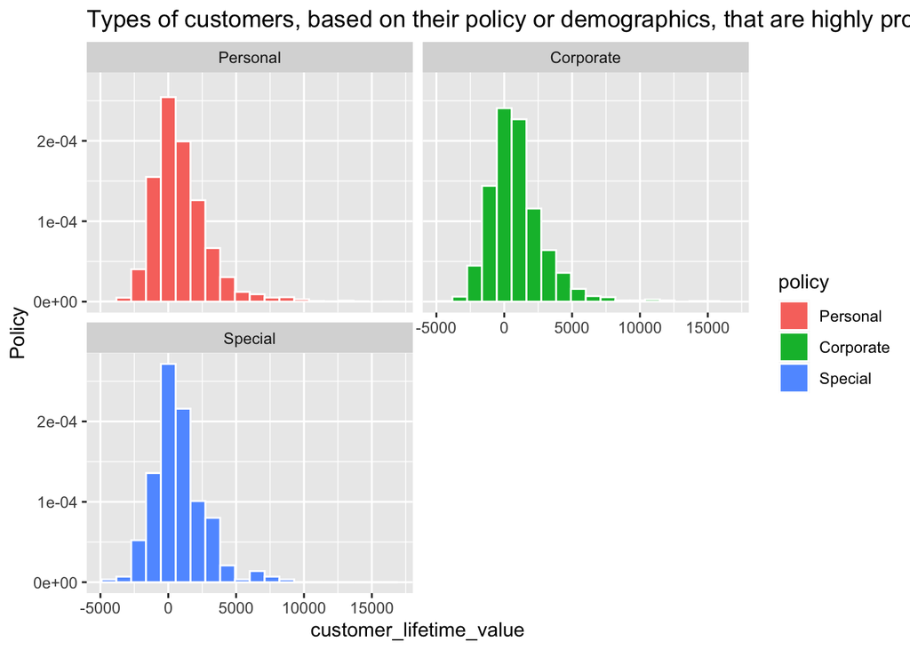

```r
ggplot(data = claims_df, aes(x = customer_lifetime_value, fill = policy)) +
   geom_histogram(aes(y = ..density..), color = "white", bins = 20) +
   facet_wrap(~ policy, nrow = 2) +
   labs(title = "Types of customers, based on their policy or demographics, that are highly profitable",
           x = "customer_lifetime_value", y = "Policy")
```

**Question**: Do certain policies have a lower number of claims, leading to large profits?

**Answer**: Based on the findings, we can conclude that the average total number of claims for all policies is 2 and that there is a positive value for the average customer lifetime value. We also have greater profit when the total number of claims is 2 as opposed to 1,3, or 4. We can also observe that there is a significant loss when the total claims are four, as seen by the negative numbers for average customer lifetime value.

```r
claims_df %>% group_by(policy,total_claims) %>%
                  summarise(customer_id = n(),
                  min_customer_lifetime_value = min(customer_lifetime_value),
                  avg_customer_lifetime_value = mean(customer_lifetime_value),
                  max_customer_lifetime_value = max(customer_lifetime_value),
                  sd_customer_lifetime_value = sd(customer_lifetime_value))
```

| policy | total_claims | customer_id | min_customer_lifetime_value | avg_customer_lifetime_value | max_customer_lifetime_value | sd_customer_lifetime_value |
| --- | --- | --- | --- | --- | --- | --- |
| Personal | 1 | 162 | -1432 | 766.9012 | 5272 | 1174.1000 |
| Personal | 2 | 2773 | -2390 | 1407.1302 | 16465 | 2073.5550 |
| Personal | 3 | 1469 | -3283 | 346.6909 | 13403 | 1881.5627 |
| Personal | 4 | 254 | -4285 | -917.5945 | 7561 | 1541.3851 |
| Corporate | 1 | 48 | -941 | 384.8750 | 3068 | 992.2481 |
| Corporate | 2 | 786 | -1844 | 1532.5280 | 15204 | 2070.0841 |
| Corporate | 3 | 421 | -3029 | 187.7340 | 8106 | 1720.5080 |
| Corporate | 4 | 73 | -3850 | -530.3973 | 8087 | 2317.3514 |
| Special | 1 | 9 | -640 | 360.8889 | 1841 | 908.5944 |
| Special | 2 | 150 | -1479 | 1297.6200 | 8934 | 1896.1532 |

[output cut: 2 more lines]

#Data Visualization

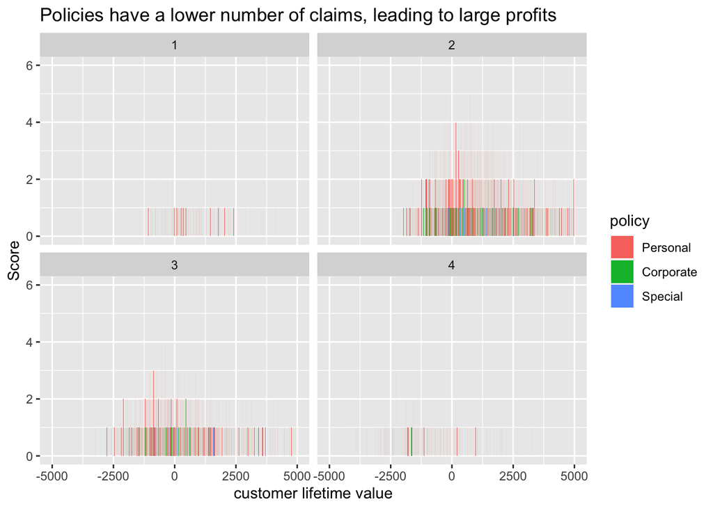

```r
ggplot(claims_df, aes(x=customer_lifetime_value,fill=policy))+
geom_bar(stat="count")+
  facet_wrap(~total_claims,nrow=2)+ xlim(-5000, 5000) +
 labs(x="customer lifetime value",
         y="Score",
       title="Policies have a lower number of claims, leading to large profits")
```

**Question**: Does state effect the customer_lifetime_value ?